# Integrating Automated Agents Into Single-Engine Cockpit Operations: A Developmental Study

Brock Rouser

# Background

## Summary of Aircraft Evaluations

Aircraft design and development in commercial and military sectors has progressed at a rapid pace from powered flight in 1903 to modern automated and unmanned systems. Design evaluation in aviation is multidisciplinary including individual subsystem design evaluations. Traditionally subsystems can be evaluated in isolation easily such as in wind tunnel testing and CFD simulations.

However, overall aircraft characteristics which stem from the combination of various subsystems is evaluated using test pilot feedback which is often limited due to sample size. Additionally, pilot feedback is usually captured via subjective self assessment which can be prone to bias and may not capture intricacies between individual aircraft subsystems.

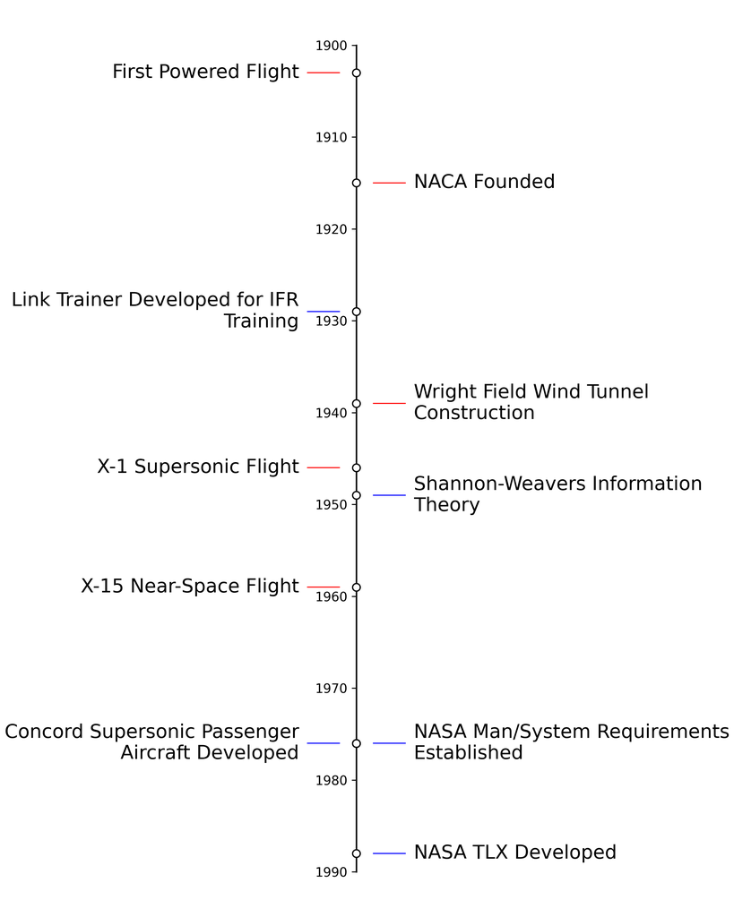

*Brief History*<sup>[1]</sup>

## Leveraging Sensors in Evaluation

Existing literature suggests a link between various physiological signals and operator states such as workload and situational awareness. With increasing accessability of sensor hardware and compute resources, studies suggest using time-series physiological sensors to quantify such operator states using sensors such as:

- Eye Trackers<sup>[2]</sup>
- Heart Rate Monitors (HRM)<sup>[3]</sup>
- Electroencephalogram (EEG)<sup>[4]</sup>
- Functional Near-Infrared Spectroscopy (fNIRS)<sup>[5]</sup>
- Galvanic Skin Response<sup>[6]</sup>

Quantifying a pilot’s physiological state using such sensing modalities may provide an additional layer of data for engineers to base decisions off of<sup>[7]</sup>. Current pilot evaluation metrics rely on self assessment tools such as:

- NASA Task Load Index (perceived workload)<sup>[8]</sup>
- Cooper-Harper Handling Qualities Rating (aircraft handling characteristics)<sup>[9]</sup>
- Situational Awareness Rating Technique (situational awareness)<sup>[10]</sup>

Such metrics derived from these self assessment surveys can be difficult to capture in a time-efficient manner and may be difficult to draw statistical significance from due to potentially small sample sizes<sup>[11]</sup>.

As organizations such as the US Navy seek to tune aircraft to fine degrees and future AI adjacent methods potentially being able to derive aircraft dynamics, additional layers of objective data become paramount<sup>[12,13,]</sup>. This data also furthers the usefulness of simulator based validation.

## Capability Development

The rise in popularity of complicated autonomous systems has shifted focus onto the pilot in aviation safety. The interplay between automation, mental workload, and situational awareness has become a topic of scrutiny as literature suggests that increased automation can result in an overall decrease in operator performance.

With readily available sensors and advanced modeling techniques, some researchers have proposed frameworks to increase pilot awareness by adapting the amount of automation in the cockpit by using various time series data channels to quantify conative states.

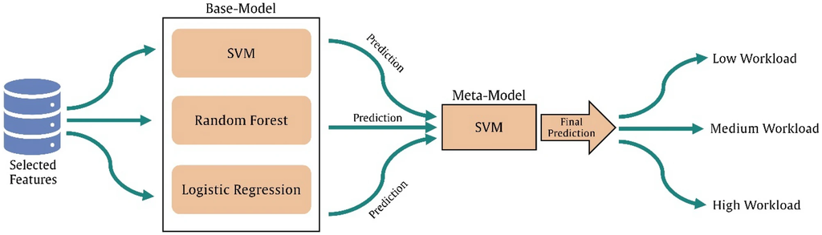

*Traditional Modeling<sup>[14]</sup>*

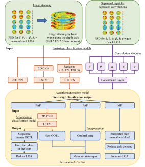

*Deep Learning<sup>[15]</sup>*

# Data Acquisition

## Data Acquisition Challenges

Utilizing a variety of physiological sensing modalities has several practical challenges that must be overcome to facilitate analysis for time-series data.

- Software Dependencies
  - Various sensor libraries provided by vendors require different operating systems, programming languages, and processor architecture (32 vs 64 bit)
- Storage
  - High frequency data from various sources should be stored in a common database in a common format
  - Due to time-series nature of the data, synchronization is paramount to a high quality analysis
- Scalability
  - Physiological data collection in an ecological setting may require different sensors for different tasks and may even need to consider multiple operators

## Current Software Architecture

To overcome these challenges, a novel data acquisition system was developed utilizing open source tools and a distributed architecture.

- Top layer uses a single control application to take in user input for testing configuration (which sensors, participant id#, etc.)
- Listeners receive configuration and manage sensor processes
- Sensors utilize MQTT Broker to route data to appropriate subscribers
- Subscribers include:
  - Common time-series database (InfluxDB)
  - Web based visualizations for real time dashboards (Grafana)
  - Real time processing applications (Statistical models)

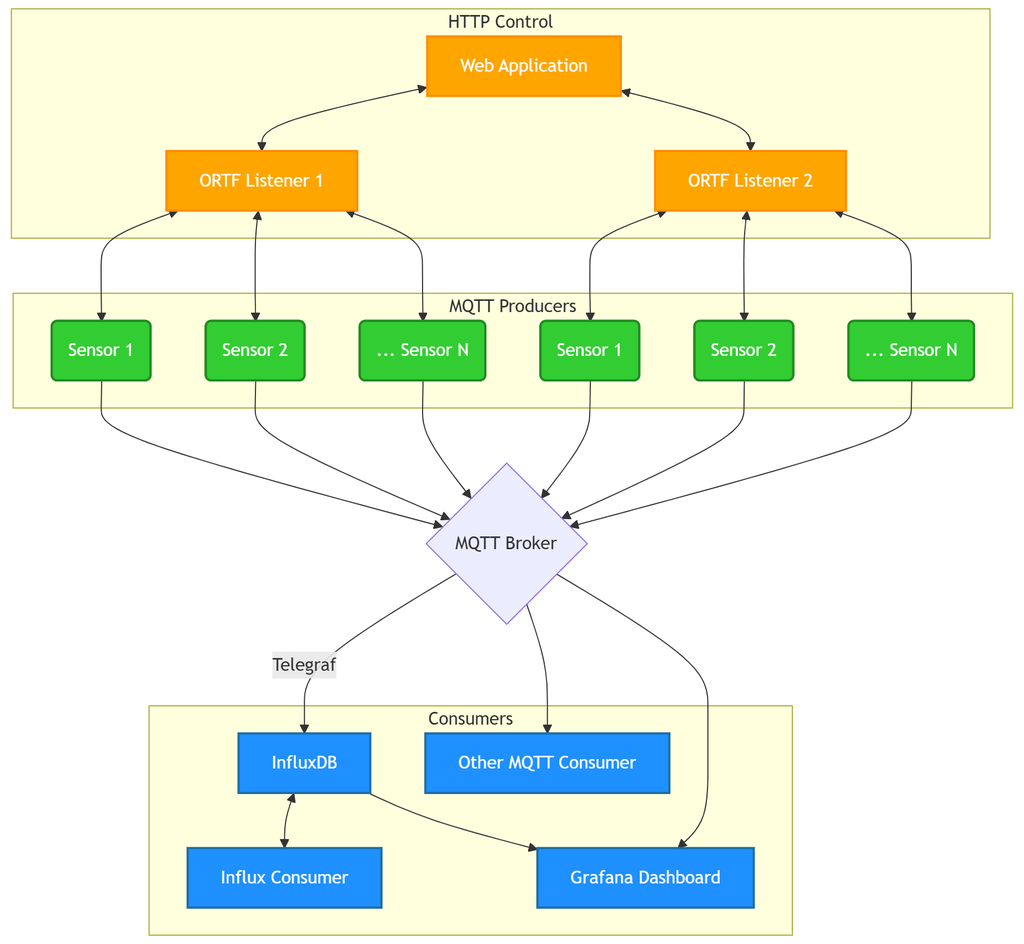

*Current Architecture*

## Development History

Initial LabVIEW Prototyping

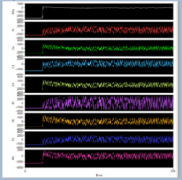

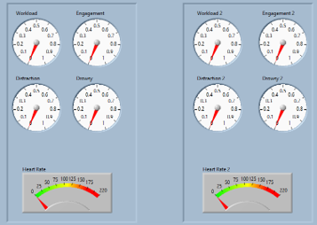

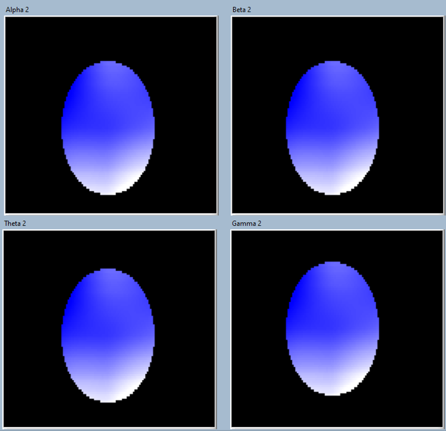

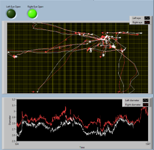

Intermediate Version

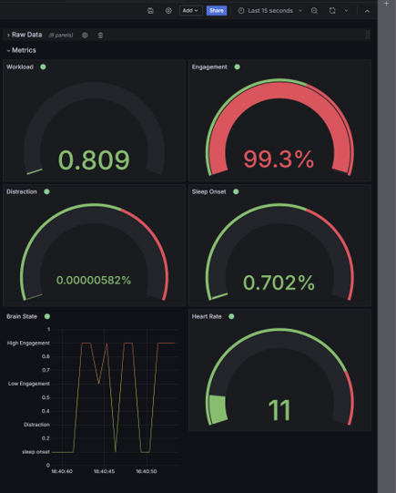

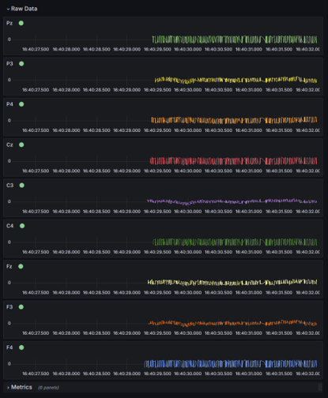

## Operational Realism Test Framework

[figure not shown]

[figure not shown]

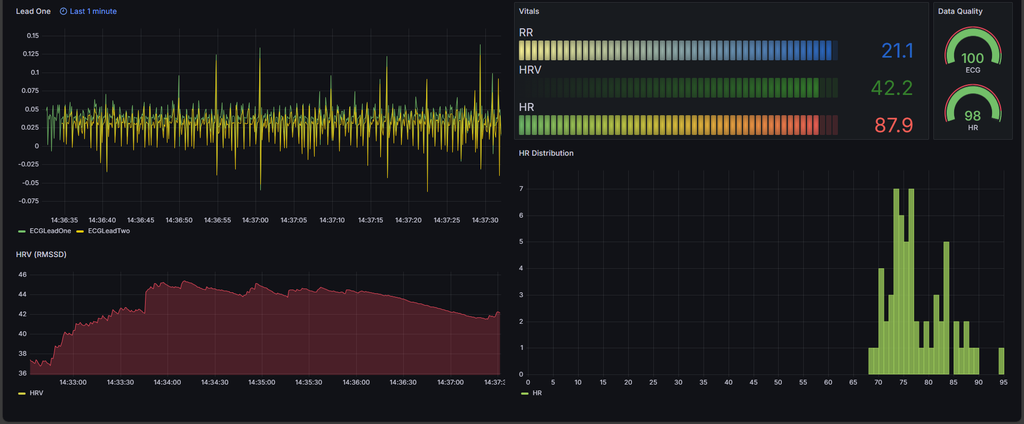

# Experimental Work

## Workload and Automation

First battery of tests were focused on evaluating sensor capabilities and inferential modeling of multivariate physiological datasets. Experimental procedures focused on two independent variables.

- Working memory load via secondary task (n-back)
- Automation state (autopilot on/off)

Data acquired included EEG, HRM, NASA-TLX, and flight metrics. The total dataset exported from the common time-series database contained ~145 million records.

Initial frequentist analysis failed when modeling physiological data due to invalid assumptions of independence and linearity. Due to this, analysis utilized general multivariate mixed effects modeling with parameters optimized via Bayesian MCMC sampling.

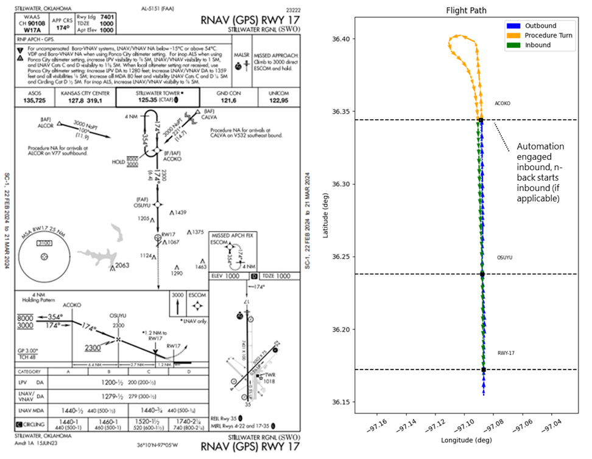

*Experimental Flight Path*

## Linear Modeling

Univariate and multivariate linear models can be optimized via ordinary least squares fitting

$$Y= \beta X + \epsilon$$

$$\beta = (X^TX)^{-1}X^Ty$$

However, this requires several assumptions which are dependant on data:

- Normality in residuals
- Linear parameters
- No multicolinearity
- Homoscedasticity (constant residual variance )

Assumptions such as these can be validated via statistical tests such as Mardia’s skewness/kurtosis, VIF analysis, Breusch-Pagan, etc. Violating these assumptions may result in a model that does not fit well.

## Bayesian Solution

Bayes’ theorem is expressed as:
$$P(A|B)=\frac{P(B|A) \cdot P(A)}{P(B)}$$

Considering our model parameters as a distribution allows for estimation via application of this theorem.

$$P(\beta | y,X)=\frac{P(y| \beta, X) \cdot P(\beta | X)}{P(y | X)}$$

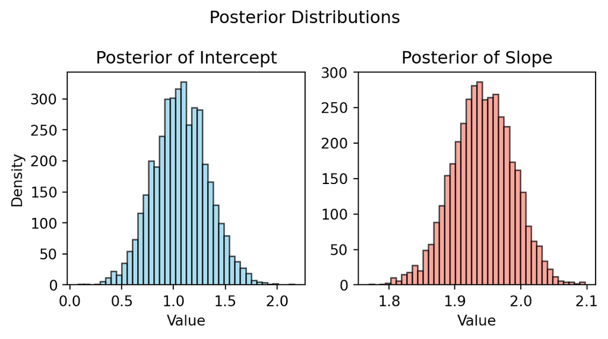

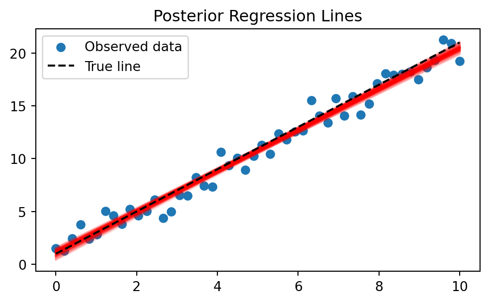

## Results

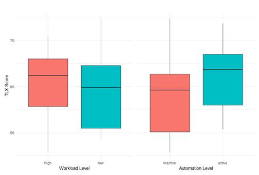

*TLX Ranges*

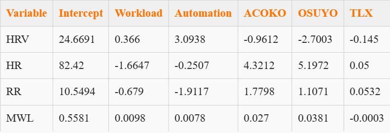

*Mean Parameters From Distributions*

Takeaways

- For a sample size of 5 participants under 4 different experimental conditions TLX didn’t indicate any statistical significant change across conditions even when included as a predictor in the model.
- Physiological metrics show meaningful change across workload and automation conditions
  - HRV increases across test conditions but decreases within flight phases
  - HR/RR shows inverse relationship to HRV which is expected
  - MWL indicates statistically significant relationship but is likely designed for working memory
- Incorporating channels such as power spectral densities for EEG electrodes may provide additional insights but increases model complexity
- These findings support time-series analysis such as feature extraction in order to better infer what is significant across participants

## Spatial Disorientation

Continuing experimentation focused on the concept of spatial disorientation (SD) in aviation. This study investigated the physiological and cognitive effects of an induced SD illusion during simulated flight using multimodal sensor data.

- Visual and vestibular illusions administered via motion decoupling
- Data acquired included EEG, HRM, NASA-TLX, and flight metrics

A similar analysis approach was utilized after frequentist modeling checks failed. Additionally, this study focused on exploring different priors for model parameters

[figure not shown]

*Fight Simulator*

## Model Checks

A limitation of Bayesian General Linear Modeling is the potential bias introduced when using improper priors. All channels passed statistical tests for univariate normality, but failed for multivariate normality.

Two families of distributions were used as priors for HR/RR and posterior predictive checks were conducted to evaluate model fit.

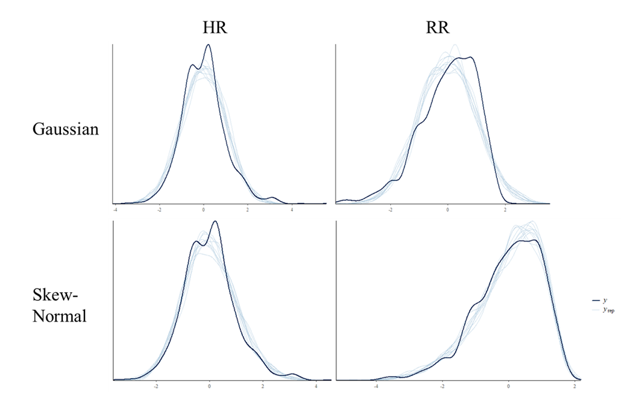

## Model Comparison

Subsets of EEG/Lifemonitor response variables compared to combined set and use of residual correlation estimated evaluated

- ELPD difference indicates how closely two models differ in their posterior predictions
- Best model indicated by 0 ELPD difference
- SE difference indicates the difference in standard error between two models

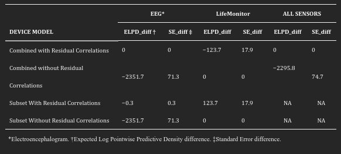

## Final Model Parameters

Final model utilized Gaussian priors to allow for estimation of residual covariance. Values of parameters indicate the normalized change in the response variable during SD illusions.

- Horizontal lines indicates mean and 1st quantile for each channel
- X-axis width for each channel indicates likelihood of the parameter value
- Captures variance and uncertainty in physiological channels changing with periods of SD illusions

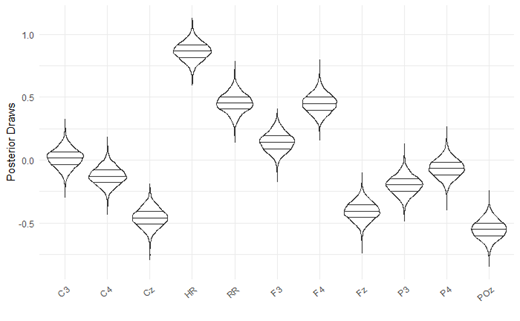

## Physiological Correlates of Cognitive States

The developed capability to collect and analyze physiological data in ecological environments poses many challenges when considering real-time applications. The two experiments conducted showcase the confounding nature of EEG responses across cognitive states such as mental workload, engagement, and spatial/situational awareness. The modeling displayed in these results highlights how the complicated nature of physiological datasets lends itself to equally complex modeling techniques. Complex algorithms have become more ubiquitous and may be able to lend predictability over readability. Such models include:

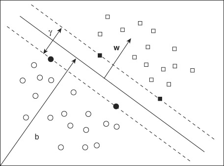

*Support Vector Machines<sup>[16]</sup>*

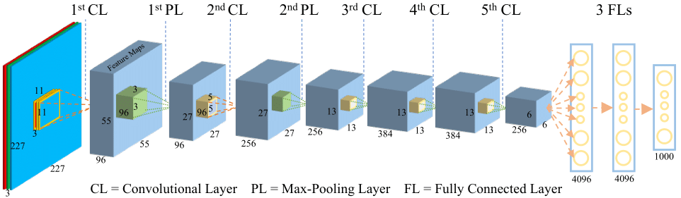

*Convolutional Neural Networks<sup>[17]</sup>*

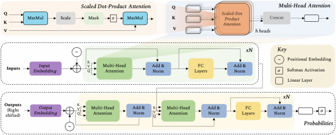

*Vision Transformers<sup>[18]</sup>*

# Adaptive Automation

## Adaptive vs Adaptable Automation

The National Highway Traffic Safety Administration has formalized levels of autonomy in vehicles. In the most extreme examples of autonomous systems such as full self driving cars the level of autonomy is decided by the driver. This is an example of adaptable automation.

Adaptive automation refers to autonomous systems in which the system itself adjusts its level of autonomy in response to certain conditions. An example of this is auto ground collision avoidance system in the F-35.

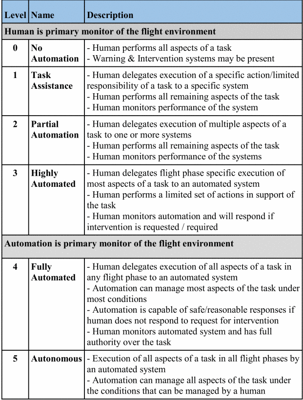

*Levels of Autonomy<sup>[19]</sup>*

## Agentic vs Advisory Systems and Levels of Autonomy

Due to the rise of agentic AI capable of taking in information, planning, and executing tasks, it may not be long until such systems are implemented in the aviation sector.

The use of physiological data may benefit the development of such systems. Leveraging ecologically valid data may both benefit developers as an additional real-time stream of pilot state as well as evaluators who need to be able to assess whether an autonomous system is actually helpful from a human factors perspective.

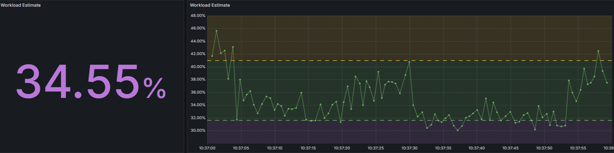

*Preliminary Advisory Display*

## Current Capability

A preliminary deep learning model was built and deployed in the ATRC flight simulator. Such model development is iterative and should consider how underlying physiological channels should be cleaned and integration of contextual information.

The capability being developed allows for previously theorized agentic and adaptive workload frameworks to be tested and evaluated in real time.

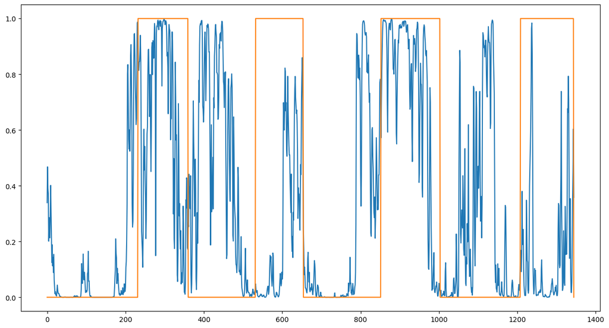

*Preliminary Workload Model*

## Preliminary Results

- Existing work showed statistical significance of processed time-series data
  - Power Spectral Densities
  - Heart/Respiratory Rate
  - Heart Rate Variability
- By letting a deep learning model analyze the raw data, it can infer these processed features naturally and draw significance
- A flaw in previous DAQ version caused significant data loss for preliminary model
- New EEG data is currently being collected. A cleaning pipeline using independent component analysis is currently under construction

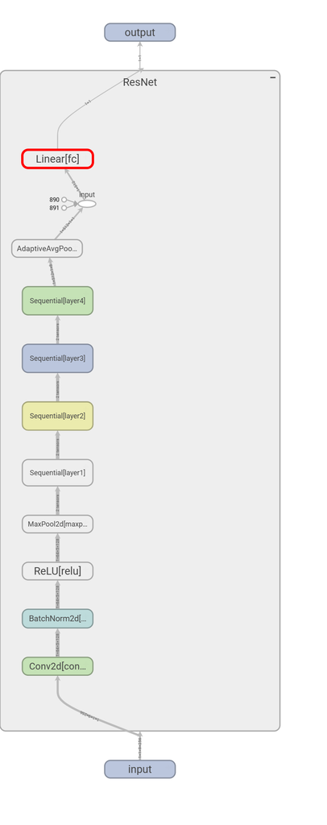

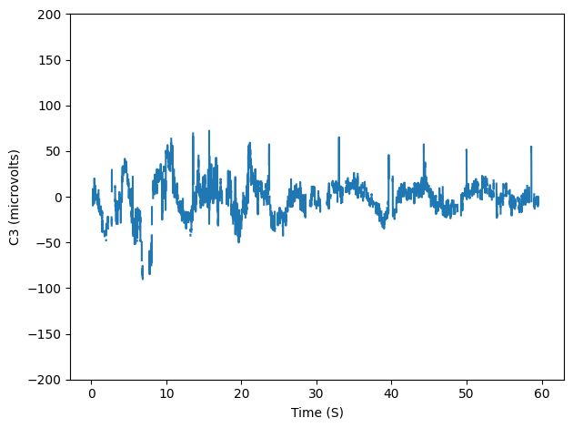

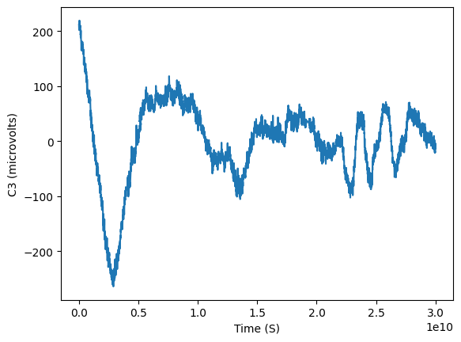

# Conclusion

## Plan and Proposal

The overarching gaps in literature this contribution seeks to fill are the following

- What are the practical limitations to implementing adaptive automation in aviation?
  - Display design
  - Trust in automation
  - Tradeoffs between workload an automation
- Is adaptive automation better than adaptable?
- Should the level of autonomy be constrained? And if so, by how much?

The proposed methodology for this work includes the following

- Collection of contextual and physiological data in a variety of environments
  - Flight simulators
  - Multi-Attribute Task Battery (MATB)
  - Other virtual environments
- Development and usage of deep learning models trained on physiological data
  - Bayesian optimization
  - Multiclass outputs
  - Hybrid models

Project Risks

- Data Collection
  - IRB Logistics
  - Sample size
  - Normalization
- Training And Development
  - Memory/compute power
  - Vanishing/exploding gradients
  - Overfitting
  - Prediction speed for real-time application

## Timeline

1. Finish collecting flight simulator data
   - Conclude: end-February, 2026
2. New model training
   - Begin: end-February, 2026
   - Conclude: end-March, 2026
3. Deploy model in flight simulator
   - Begin: end-March, 2026
   - Conclude: end-May, 2026
4. Evaluate and publish experimental results
   - Begin: end-May, 2026
   - Conclude: end-June, 2026
5. Begin iterative model development
   - Begin: July, 2026
   - Conclude: September, 2026
6. Conduct experimental model validation and compare with previous results
   - Begin: September, 2026
   - Conclude: end-September, 2026
7. Compile results and evaluate existing adaptive automation frameworks
   - Begin: October, 2026
   - Conclude: December, 2026

## Academic Products

- *Quantifying Pilot Performance and Mental Workload in Modern Aviation Systems: A Scoping Literature Review*<sup>[20]</sup>: Secondary author. Published in Aerospace [IF = 2.1], July 2025
- *Characterizing Spatial Disorientation in Flight Simulation Through Electroencephalogram Trends*: Primary author. Accepted in Aerospace Medical Association [IF=0.9], November 2025
- *Feasibility Evaluation of a Real-Time Multimodal Data Acquisition System and Bayesian Multivariate Modeling of Pilot Mental Workload in a Flight Simulator*: Primary author. Submitted to Sci Reports in April 2025 after 6 months working through public release at sponsor. Subsequently submitted to Human Factors and Ergonomics in Manufacturing & Service Industries, September 2025
- *Development of a Scalable Data Acquisition System for Multimodal Physiological Data for Human Factors Research*<sup>[21]</sup>: Primary author. Published in Proceedings of the Human Factors and Ergonomics Society Annual Meeting, October 2025
- *Hierarchical Bayesian Modeling for Physiological Data in Small-N Aviation Human Factors Research*<sup>[22]</sup>: Secondary author. Published in Aerospace [IF = 2.1], November 2025
- *Lawton FISTA CSIE #3 Supporting Fort Sill Operations*<sup>[23]</sup>: Contributing author. Published in Defense Technical Information Center (Distro D), June 2025
- *Human Factors Testbed Instrumentation Design Document*<sup>[24]</sup>: Contributing author. Published in Defense Technical Information Center (Distro D), January 2025

# Feedback

## References

1. Wiener, E. L., & Nagel, D. C. (1988). *Human factors in aviation*. Gulf Professional Publishing.

2. Cheng, L., Shen, Y.-C., He, Q., & Zhang, M.-J. (2024). Spying with a pilot&#x2019;s eye: Using eye tracking to investigate pilots&#x2019; attention allocation and workload during helicopter autorotative gliding. *Heliyon*, *10*(16). https://doi.org/10.1016/j.heliyon.2024.e35872

3. Masi, G., Amprimo, G., Ferraris, C., & Priano, L. (2023). Stress and workload assessment in aviation—a narrative review. *Sensors*, *23*(7). https://doi.org/10.3390/s23073556

4. Salvan, L., Paul, T. S., & Marois, A. (2023). Dry EEG-based mental workload prediction for aviation. *2023 IEEE/AIAA 42nd Digital Avionics Systems Conference (DASC)*, 1–8. https://doi.org/10.1109/DASC58513.2023.10311163

5. Zhang, C., Jiang, C., Xie, Y., Cao, S., Yuan, J., Liu, C., Cao, W., & Li, Y. (2025). Assessing pilot workload during takeoff and climb under different weather conditions: A fNIRS-based modeling using deep learning algorithms. *IEEE Transactions on Aerospace and Electronic Systems*, *61*(2), 1705–1724. https://doi.org/10.1109/TAES.2024.3458954

6. Calado, A. S. A., Fernandes, T. F. R., Silva, H. H. P. da, & Brito André, P. S. de. (2025). Towards psychophysiological monitoring of aircraft pilot crew. In C. Marques, R. V. L. N. Sridhar, & S. Kumar (Eds.), *Advanced optical sensors for aerospace applications* (pp. 363–391). Springer Nature Singapore. https://doi.org/10.1007/978-981-95-1626-1_12

7. Hankins, T. C., & Wilson, G. F. (1998). A comparison of heart rate, eye activity, EEG and subjective measures of pilot mental workload during flight. *Aviation, Space, and Environmental Medicine*, *69*(4), 360–367.

8. Hart, S. G. (2006). Nasa-task load index (NASA-TLX); 20 years later. *Proceedings of the Human Factors and Ergonomics Society Annual Meeting*, *50*(9), 904–908. https://doi.org/10.1177/154193120605000909

9. Mitchell, D. G. (n.d.). Fifty years of the cooper-harper scale. In *AIAA scitech 2019 forum*. https://doi.org/10.2514/6.2019-0563

10. Taylor, R. M. (2017). Situational awareness rating technique (SART): The development of a tool for aircrew systems design. In *Situational awareness* (pp. 111–128). Routledge.

11. Bolton, M. L., Biltekoff, E., & Humphrey, L. (2023). The mathematical meaninglessness of the NASA task load index: A level of measurement analysis. *IEEE Transactions on Human-Machine Systems*, *53*(3), 590–599. https://doi.org/10.1109/THMS.2023.3263482

12. Paul, R., & Rhinehart, M. (2023). *Exploring pilot workload using inceptor time histories*.

13. Dong, Y., Tao, J., Zhang, Y., Lin, W., & Ai, J. (2021). Deep learning in aircraft design, dynamics, and control: Review and prospects. *IEEE Transactions on Aerospace and Electronic Systems*, *57*(4), 2346–2368. https://doi.org/10.1109/TAES.2021.3056086

14. Taheri Gorji, H., Wilson, N., VanBree, J., Hoffmann, B., Petros, T., & Tavakolian, K. (2023). Using machine learning methods and EEG to discriminate aircraft pilot cognitive workload during flight. *Scientific Reports*, *13*(1), 2507. https://doi.org/10.1038/s41598-023-29647-0

15. Yiu, C. Y., Ng, K. K. H., Li, Q., & Yuan, X. (2025). Keeping pilots in the loop: An explainable spatiotemporal EEG-driven deep learning framework for adaptive automation in cruising flight phase. *IEEE Transactions on Intelligent Transportation Systems*, *26*(7), 9838–9851. https://doi.org/10.1109/TITS.2025.3567987

16. Mammone, A., Turchi, M., & Cristianini, N. (2009). Support vector machines. *WIREs Computational Statistics*, *1*(3), 283–289. https://doi.org/https://doi.org/10.1002/wics.49

17. Qin, Z., Yu, F., Liu, C., & Chen, X. (2018). *How convolutional neural network see the world - a survey of convolutional neural network visualization methods*. https://arxiv.org/abs/1804.11191

18. Khan, S., Naseer, M., Hayat, M., Zamir, S. W., Khan, F. S., & Shah, M. (2022). Transformers in vision: A survey. *ACM Comput. Surv.*, *54*(10s). https://doi.org/10.1145/3505244

19. Anderson, E., Fannin, T., & Nelson, B. (2018). Levels of aviation autonomy. *2018 IEEE/AIAA 37th Digital Avionics Systems Conference (DASC)*, 1–8. https://doi.org/10.1109/DASC.2018.8569280

20. Kyle, A. R., Rouser, B., Paul, R. C., & Jurewicz, K. A. (2025). Quantifying pilot performance and mental workload in modern aviation systems: A scoping literature review. *Aerospace*, *12*(7). https://doi.org/10.3390/aerospace12070626

21. Rouser, B., Kyle, A., Jurewicz, K., & Paul, R. (2025). Development of a scalable data acquisition system for multimodal physiological data for human factors research. *Proceedings of the Human Factors and Ergonomics Society Annual Meeting*, *69*(1), 1902–1904. https://doi.org/10.1177/10711813251367735

22. Kyle, A., Rouser, B., Paul, R. C., & Jurewicz, K. A. (2025). Hierarchical bayesian modeling for physiological data in small-n aviation human factors research. *Aerospace*, *12*(11). https://doi.org/10.3390/aerospace12111004

23. Paul, R., Jurewicz, K., & Rouser, B. (2025). *Lawton FISTA CSIE #3 supporting fort sill operations* [Technical Report]. Army Aviation Missile Center.

24. Paul, R., Jurewicz, K., Parnell, S., & Rouser, B. (2025). *Human factors testbed instrumentation design document* [Technical Report]. Army Aviation Missile Center.